# project_report

Allegra Frickel

4/25/2019

# Minimum Wages

Minimum wage has by and large been a topic of discussion in recent years. Between those who argue for and against increasing minimum wage, there are several external factors that influence the decision to increase or keep the minimum wage level. But one question remains certain: what was minimum wage in the past, and what does the trend of minimum wage levels look like in the last 50 years among the states?

The United States Department of Labor published the minimum wage rates for each state, ranging from 1968 to 2017. Each of these rates has a 2018-dollar equivalent that can be used to determine inflation rates and display fluctuation.

The cleaned version of the Department of Labor’s data, which was provided on Kaggle, was relatively clean. For the purpose of this investigation, state, year, implemented minimum wage, 2018-dollar equivalent and CPI Average columns were used.

**Pipeline for Cleaning**

Cleaning for this investigation was relatively simple. Outside of deleting two columns that did not contain valuable information, the NA values, data types, factoring, etc. was already done. It is logical to delete Table_Data and Footnote columns because they are not useful for the purpose of this project.

```
## [1] "Year"        "State"       "Table_Data"  "Footnote"    "High.Value"
## [6] "Low.Value"   "CPI.Average" "High.2018"   "Low.2018"
```

```
##   Year   State Table_Data Footnote High.Value Low.Value CPI.Average
## 1 1968 Alabama        ...                 0.0       0.0    34.78333
## 2 1968  Alaska        2.1                 2.1       2.1    34.78333
##   High.2018 Low.2018
## 1      0.00     0.00
## 2     15.12    15.12
```

```
##   Year   State High.Value Low.Value CPI.Average High.2018 Low.2018
## 1 1968 Alabama       0.00     0.000    34.78333      0.00     0.00
## 2 1968  Alaska       2.10     2.100    34.78333     15.12    15.12
## 3 1968 Arizona       0.66     0.468    34.78333      4.75     3.37
```

**Exploratory Analysis and Visualization:**

**Minimum Wages Over Time in Relation to Federal Minimum Wage**

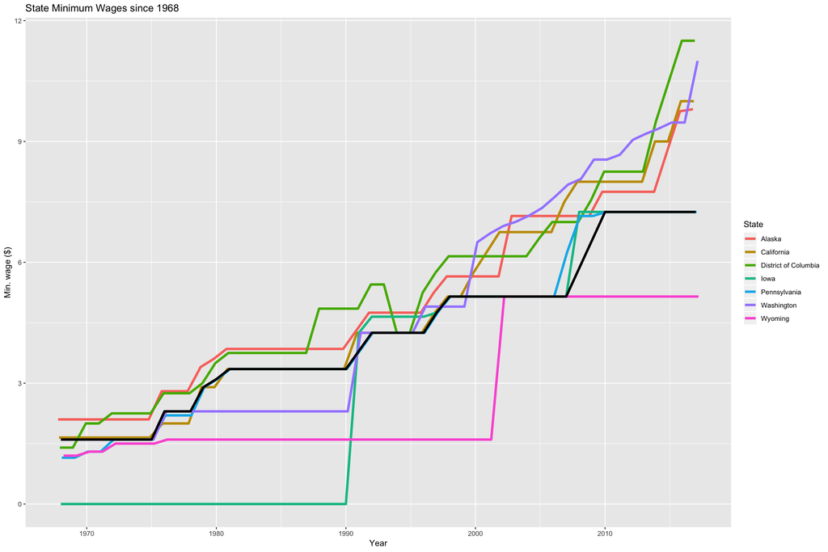

This figure displays states’ minimum wages over time. These states are the states tht have more extreme flucuations in minimum wage rates. The black line represents the federal minimum wage level over time.

Iowa’s line displays no establishment of a minimum wage until 1990. 1990 establishes a minimum wage at the federal minimum wage level. On the opposite end, Washington D.C. displays a more dramatic flucuation of minimum wage. The minimum wage in Washington D.C. has mostly been above federal minimum wage. This is a similar situation with Alaska.

In later investigation, we will determine a reason for higher minimum wages is to keep up with the cost of living in that state.

**Cost of Living versus Minimum Wage**

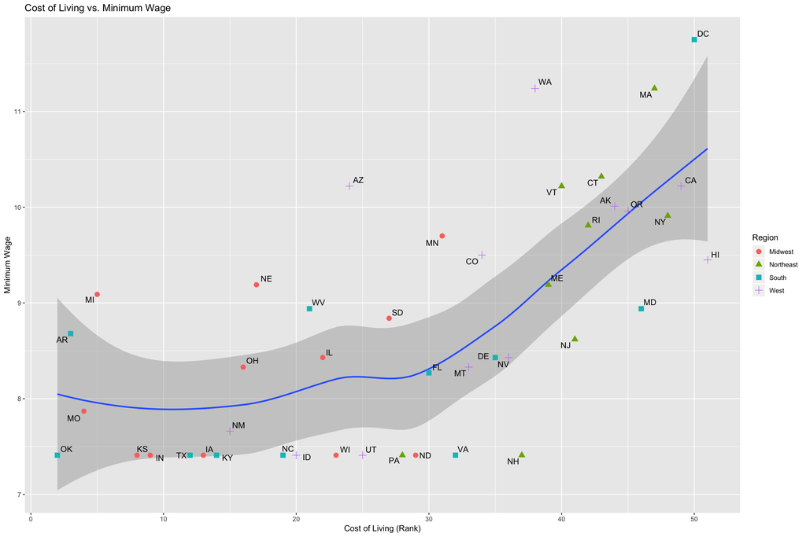

**Trends by Region**

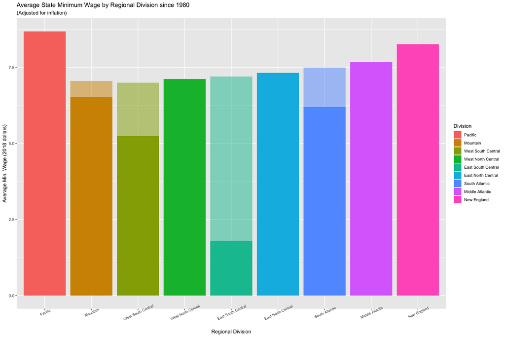

After dividing the states into the regions of the United States, the graph displays the average minimum wage in 2018-dollar amounts by each region. For instance, the Pacific, New England and Middle Atlantic regions reflect higher minimum wages. As we are shown from the above graphs, this could be because of the high cost of living along the east and west coasts of the United States.

# Personal Contributions

Allegra: Ally was the project coordinator. Ally compiled the presentation, wrote the project report and coordinated with the group members. For the presentation, Ally completed and presented the introduction, obtaining data, background of the dataset, questions raised, where to apply and contributed to the findings. Ally wrote the project report and compiled the report.

Audrey: Audrey created all of the visualizations for the presentation and report. This included exploring more of the cleaned dataset, joining other data, exploring the joined data and visualizing the manipulated data to answer our questions and achieve our overall goal. Audrey also helped write the project report. More specifically, she wrote the explanations for the graphs.

Bradley: Brad completed the exploratory analysis for the data. This included exploring the basic structure of the data and seeing what questions can be raised. In addition, Brad came up with several questions that can be answered by the data and contributed to finding the answers to those questions.

Seydou: Seydou helped Brad with the explanatory analysis. He also compiled the findings and wrote the conclusion of the presentation. The conclusion also included brainstorming ways we can further our investigation with this dataset. Seydou also helped Brad find the answers to the questions.